# Raport z analizy danych

Sandra Żrałka 106595

08 grudzień 2015

### Spis treści

Podsumowanie Ładowanie bibliotek Kod zapewniający powtarzalność wyniku Wczytanie danych Kod usuwający niedozwolone wartości Kod pozostawiający unikatowe wartości kolumn Podsumowanie kolumn Korelacja między kolumnami Liczba przykładów dla każdej klasy Rozkład liczby atomów i liczby elektronów Odwzorowanie wykresu Tabela pokazująca 10 klas z największą niezgodnością liczby atomów i elektonów Rozkład wartości kolumn zaczynających się od part 01 Sekcja sprawdzająca czy na podstawie kolumn da się przewidzieć liczbę atomów i elektronów Klasyfikator

### Podsumowanie

Celem projektu jest zapoznanie się ze zbiorem danym pochądzącym z bazy [Protein Data Bank](http://www.rcsb.org/pdb/home/home.do) analiza tych danych, a następnie przygotowanie raportu.

W projekcie zostały wykorzystane następujące biblioteki:

- knitr - ułatwiająca przejrzyste tworzenie raportów,
- dplyr - ułatwiająca pracę na data.freme’ach,
- RColorBrewer - ułatwiająca operowanie kolorami,
- corrplot - umożliwiająca wizualne przedtawienie korelacji,
- ggplot2 - umożliwiająca graficzną analizę danych,
- MASS - potrzebna do użycia funckji kde2d - służącej do wyznaczenia dwuwymiarowego jądrowego estymatora gęstości,
- caret - ułatwiająca tworzenie klasyfikatorów oraz modeli regresji.

W celu zapewnienia powtarzalności losowych wyników wykorzystano funkcję set.seed(). Dane zostały załadowane z pliku all_summary.csv.

Aby usunąć niedozwolone klasy res_name, w sekcji 4 został utworzony wektor, zawierający zbędne wartości, który w następnej sekcji został wykorzystany w funkcji filter, do ograniczenia zbioru danych. W celu uniknięcia przeuczenia klasyfikatora, ograniczono się do kolumn zawierających unikalną kombinację kolumn pdb_code oraz res_name.

W kolejnej sekcji znajduje się tabela przedstawiająca podsumowanie wszystkich kolumn analizowanego zbioru danych, która pozwoliła na określenie, które kolumny powinny zostać wykorzystane do wizualnego przedstawienia korelacji, a które przy tworzeniu klasyfikatora.

Sekcja 7 przedstawia korelację pomiędzy kolumnami zbioru danych zawierających wartości numeryczne. Na wykresach nie uwzględniono kolumn rozpoczynających się od “part_”, ponieważ występuje w nich dużo wartości NA. W celu zwiększenia czytelności kolumny zostały podzielone na 2 grupy, które są w bardzo niewielkim stopniu lub w ogóle nie są wzajemnie skorelowane.

Kolejne dwie sekcje pozwalają na zauważenie zależności pomiędzy liczbą elektronów oraz liczbą atomów w cząsteczce.

Sekcja 11 prezentuje tabele, które obrazują różnicę średnich między rzeczywistą, a przewidywaną liczbą atomów/elektornów. W każdej z klas uwzględniono 10 klas o największych różnicach.

Sekcja 12 obrazuje rozkłady wartości dla kolumn, których nazwy rozpoczynają się od part 01. Na wykresach można zauważyć, że niektóre kolumny posiadają obserwacje odstające - outlier, które znacząco wpływają na wartość średnią i mogłyby wpływać na wynik klasyfikacji.

W następnej sekcji można zauważyć, że na podstawie wartości innych kolumn można z dużą dokładnością przewidzieć liczbę atomów oraz liczbę elektronów przy niskiej średniej kwadratowej błędów. Następnie wylistowano kolumny, które w dużym stopniu wpływają na jakość tego wyniku. Tak jak pokazały to już sekcja 10 i 11 widać wyraźnie zależność między liczbą atomów i elektronów.

### Ładowanie bibliotek

```r
library(knitr)
library(dplyr)
library(corrplot)
library(ggplot2)
library(RColorBrewer)
library(MASS)
library(caret)
```

### Kod zapewniający powtarzalność wyniku

```r
set.seed(23)
```

### Wczytanie danych

```r
d <- read.csv(file="all_summary.csv", sep=";")
```

### Kod usuwający niedozwolone wartości

```r
forbidden_values <- c("DA","DC","DT", "DU", "DG", "DI","UNK", "UNX", "UNL", "PR", "PD", "Y1", "EU", "N", "15P", "UQ", "PX4", "NAN")
```

### Kod pozostawiający unikatowe wartości kolumn

```r
filtered_values <- d %>%
                  filter(!(res_name %in% forbidden_values)) %>%
                  mutate(key_value=paste(pdb_code, res_name, sep=" " )) %>%
                  distinct(key_value)
```

### Podsumowanie kolumn

|  | title | pdb_code | res_name | res_id | chain_id | local_BAa | local_NPa | local_Ra | local_RGa | local_SRGa | local_CCSa | local_CCPa | local_ZOa | local_ZDa | local_ZD_minus_a | local_ZD_plus_a | local_res_atom_count | local_res_atom_non_h_count | local_res_atom_non_h_occupancy_sum | local_res_atom_non_h_electron_sum | local_res_atom_non_h_electron_occupancy_sum | local_res_atom_C_count | local_res_atom_N_count | local_res_atom_O_count | local_res_atom_S_count | dict_atom_non_h_count | dict_atom_non_h_electron_sum | dict_atom_C_count | dict_atom_N_count | … |
| --- | --- | --- | --- | --- | --- | --- | --- | --- | --- | --- | --- | --- | --- | --- | --- | --- | --- | --- | --- | --- | --- | --- | --- | --- | --- | --- | --- | --- | --- | --- |
|  | 110l BME 901 A: 1 | 3ag4 : 16 | SO4 : 1183 | 301 : 430 | A :8630 | Min. : NA | Min. : NA | Min. : NA | Min. : NA | Min. : NA | Min. : NA | Min. : NA | Min. : NA | Min. : NA | Min. : NA | Min. : NA | Min. : 1.00 | Min. : 1.00 | Min. : 0.00 | Min. : 3.0 | Min. : 0.00 | Min. : 0.000 | Min. : 0.00 | Min. : 0.000 | Min. :0.0000 | Min. : 1.00 | Min. : 3.0 | Min. : 0.00 | Min. : 0.000 | … |
|  | 111l CL 173 A : 1 | 3abl : 15 | ZN : 849 | 1 : 424 | B :2905 | 1st Qu.: NA | 1st Qu.: NA | 1st Qu.: NA | 1st Qu.: NA | 1st Qu.: NA | 1st Qu.: NA | 1st Qu.: NA | 1st Qu.: NA | 1st Qu.: NA | 1st Qu.: NA | 1st Qu.: NA | 1st Qu.: 1.00 | 1st Qu.: 1.00 | 1st Qu.: 1.00 | 1st Qu.: 30.0 | 1st Qu.: 30.00 | 1st Qu.: 0.000 | 1st Qu.: 0.00 | 1st Qu.: 0.000 | 1st Qu.:0.0000 | 1st Qu.: 1.00 | 1st Qu.: 30.0 | 1st Qu.: 0.00 | 1st Qu.: 0.000 | … |
|  | 115l BME 901 A: 1 | 3abk : 14 | GOL : 778 | 501 : 417 | C : 795 | Median : NA | Median : NA | Median : NA | Median : NA | Median : NA | Median : NA | Median : NA | Median : NA | Median : NA | Median : NA | Median : NA | Median : 7.00 | Median : 7.00 | Median : 7.00 | Median : 55.0 | Median : 52.00 | Median : 3.000 | Median : 0.00 | Median : 3.000 | Median :0.0000 | Median : 7.00 | Median : 56.0 | Median : 3.00 | Median : 0.000 | … |
|  | 115l CL 173 A : 1 | 2afh : 11 | CA : 661 | 401 : 395 | D : 552 | Mean :NaN | Mean :NaN | Mean :NaN | Mean :NaN | Mean :NaN | Mean :NaN | Mean :NaN | Mean :NaN | Mean :NaN | Mean :NaN | Mean :NaN | Mean : 13.59 | Mean : 13.43 | Mean : 13.05 | Mean :101.5 | Mean : 98.33 | Mean : 7.332 | Mean : 1.35 | Mean : 3.817 | Mean :0.2208 | Mean : 13.74 | Mean :103.8 | Mean : 7.47 | Mean : 1.357 | … |
|  | 123l BME 901 A: 1 | 3a0b : 11 | MG : 402 | 201 : 306 | E : 221 | 3rd Qu.: NA | 3rd Qu.: NA | 3rd Qu.: NA | 3rd Qu.: NA | 3rd Qu.: NA | 3rd Qu.: NA | 3rd Qu.: NA | 3rd Qu.: NA | 3rd Qu.: NA | 3rd Qu.: NA | 3rd Qu.: NA | 3rd Qu.: 21.00 | 3rd Qu.: 20.00 | 3rd Qu.: 20.00 | 3rd Qu.:145.0 | 3rd Qu.:139.15 | 3rd Qu.:10.000 | 3rd Qu.: 2.00 | 3rd Qu.: 5.000 | 3rd Qu.:0.0000 | 3rd Qu.: 21.00 | 3rd Qu.:151.0 | 3rd Qu.:10.00 | 3rd Qu.: 2.000 | … |
|  | 123l CL 173 A : 1 | 3g6e : 11 | (Other):10021 | 500 : 228 | H : 153 | Max. : NA | Max. : NA | Max. : NA | Max. : NA | Max. : NA | Max. : NA | Max. : NA | Max. : NA | Max. : NA | Max. : NA | Max. : NA | Max. :178.00 | Max. :104.00 | Max. :104.00 | Max. :800.0 | Max. :800.00 | Max. :81.000 | Max. :15.00 | Max. :55.000 | Max. :9.0000 | Max. :128.00 | Max. :866.0 | Max. :81.00 | Max. :20.000 | … |
|  | (Other) :14126 | (Other):14054 | NA’s : 238 | (Other):11932 | (Other): 876 | NA’s :14132 | NA’s :14132 | NA’s :14132 | NA’s :14132 | NA’s :14132 | NA’s :14132 | NA’s :14132 | NA’s :14132 | NA’s :14132 | NA’s :14132 | NA’s :14132 | NA | NA | NA | NA | NA | NA | NA | NA | NA | NA’s :19 | NA’s :19 | NA’s :19 | NA’s :19 | … |

### Korelacja między kolumnami

```
## [1] "#Kod pozwalający zobaczyć korelację bez podziału na podgrupy \nrm_na <-without_na[complete.cases(without_na),]\ncorgraph <- cor(rm_na)\ncorrplot(corgraph, method=\"square\", tl.cex = 0.4, tl.col = \"black\")"
```

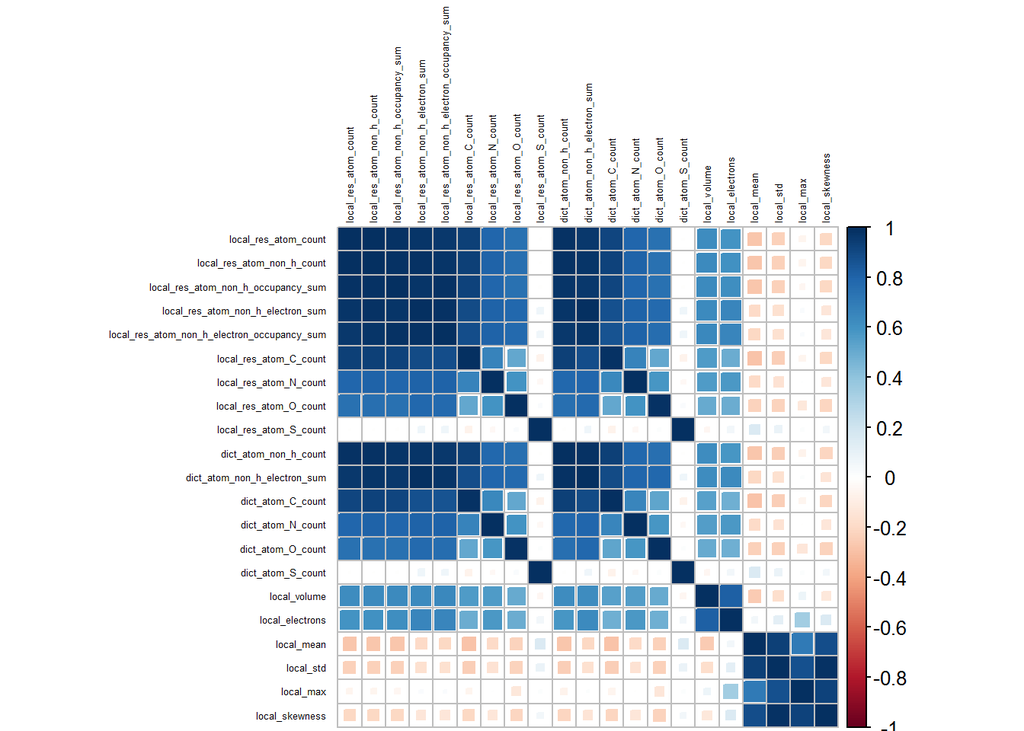

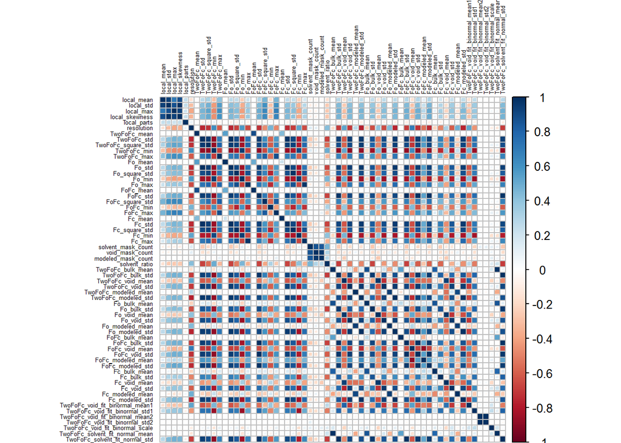

### Liczba przykładów dla każdej klasy

| res_name | count |
| --- | --- |
| SO4 | 1183 |
| ZN | 849 |
| GOL | 778 |
| CA | 661 |
| MG | 402 |
| CL | 400 |
| NAG | 396 |
| PO4 | 301 |
| HEM | 296 |
| EDO | 274 |
| NA | 238 |
| MN | 182 |
| ACT | 167 |
| FAD | 157 |
| ADP | 138 |
| FE | 120 |
| K | 119 |
| ATP | 106 |
| CU | 104 |
| PEG | 90 |
| NAP | 86 |
| CD | 81 |
| NAD | 80 |
| MES | 79 |
| NI | 76 |
| FMN | 73 |
| EPE | 72 |
| BME | 67 |
| PG4 | 67 |
| TRS | 63 |
| MAN | 62 |
| CO | 61 |
| NDP | 61 |
| SEP | 61 |
| PLP | 59 |
| CIT | 56 |
| GDP | 55 |
| MPD | 55 |
| SAH | 54 |
| FE2 | 52 |
| TPO | 50 |

### Rozkład liczby atomów i liczby elektronów

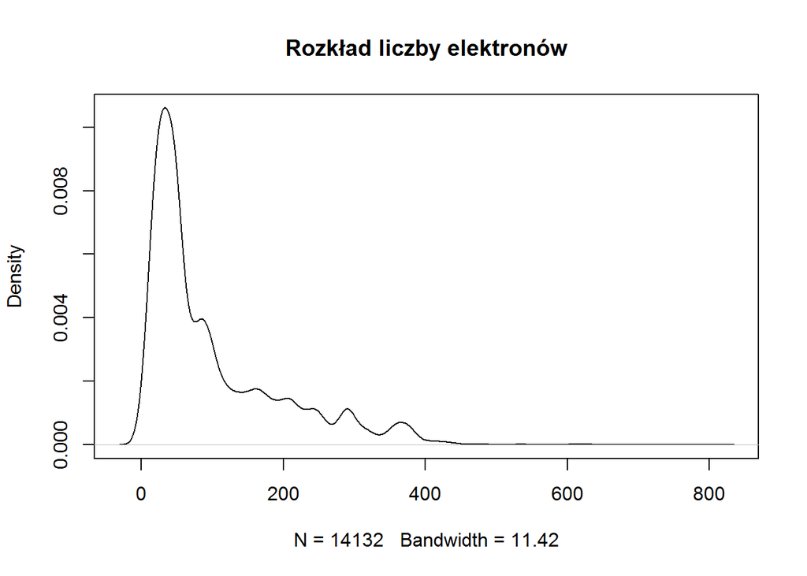

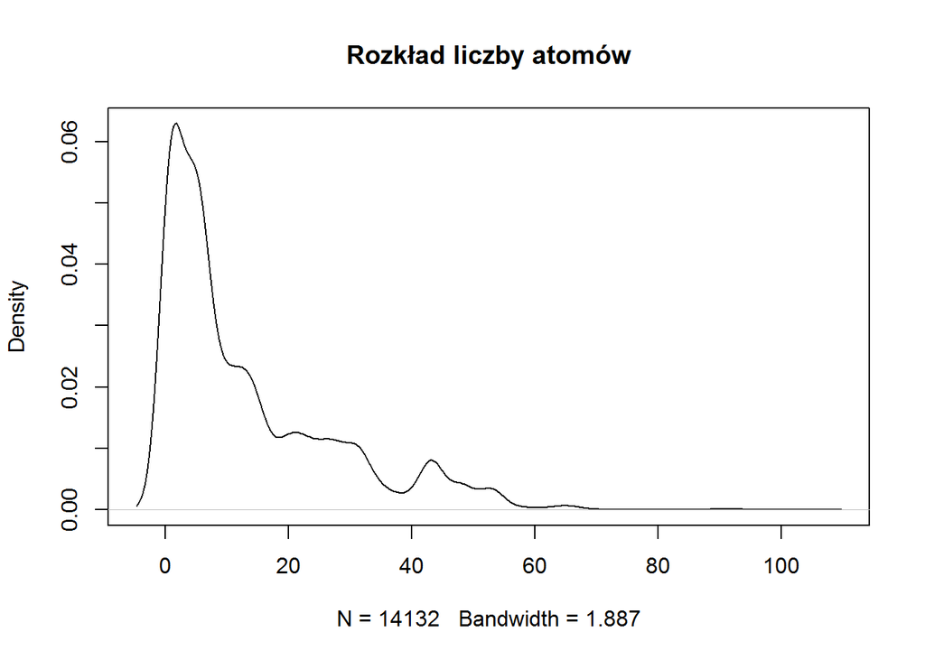

### Odwzorowanie wykresu

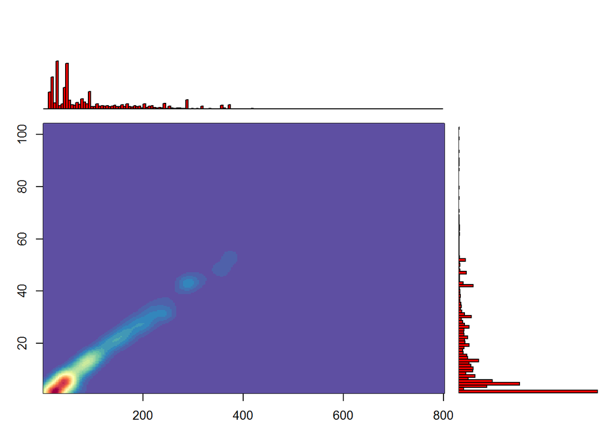

### Tabela pokazująca 10 klas z największą niezgodnością liczby atomów i elektonów

Największe niezgodności liczby atomów

| res_name | local | dict | difference |
| --- | --- | --- | --- |
| PEU | 16.50000 | 83 | 66.50000 |
| PC1 | 20.66667 | 54 | 33.33333 |
| CPQ | 27.00000 | 60 | 33.00000 |
| JEF | 8.00000 | 41 | 33.00000 |
| VV7 | 95.00000 | 128 | 33.00000 |
| M0E | 77.00000 | 109 | 32.00000 |
| PTY | 19.00000 | 50 | 31.00000 |
| LI1 | 15.50000 | 45 | 29.50000 |
| IP9 | 24.00000 | 51 | 27.00000 |
| PEF | 20.00000 | 47 | 27.00000 |

Największe niezgodności liczby elektronów

| res_name | local | dict | difference |
| --- | --- | --- | --- |
| PEU | 111.0000 | 554 | 443.0000 |
| CPQ | 168.0000 | 393 | 225.0000 |
| VV7 | 642.0000 | 866 | 224.0000 |
| JEF | 54.0000 | 267 | 213.0000 |
| PC1 | 138.3333 | 350 | 211.6667 |
| M0E | 540.0000 | 736 | 196.0000 |
| PEF | 120.0000 | 308 | 188.0000 |
| PTY | 140.0000 | 326 | 186.0000 |
| IP9 | 201.0000 | 386 | 185.0000 |
| LI1 | 93.0000 | 276 | 183.0000 |

### Rozkład wartości kolumn zaczynających się od part_01

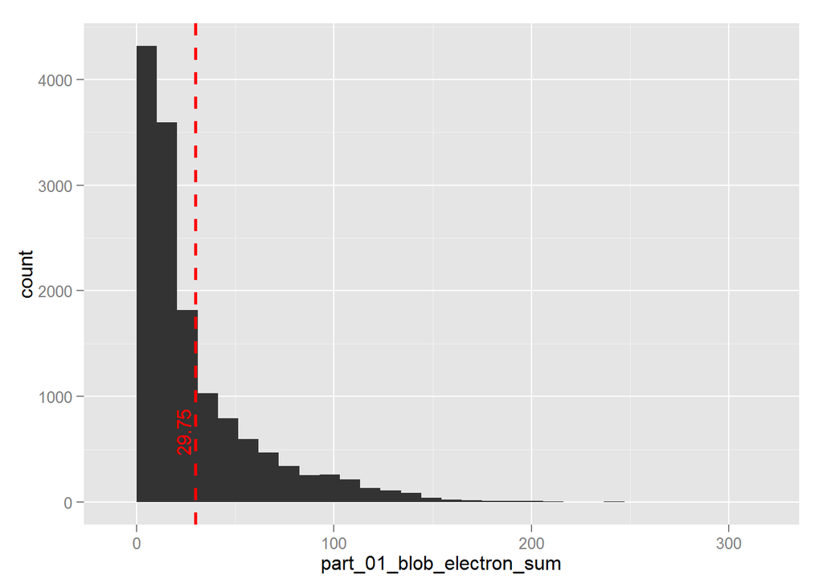

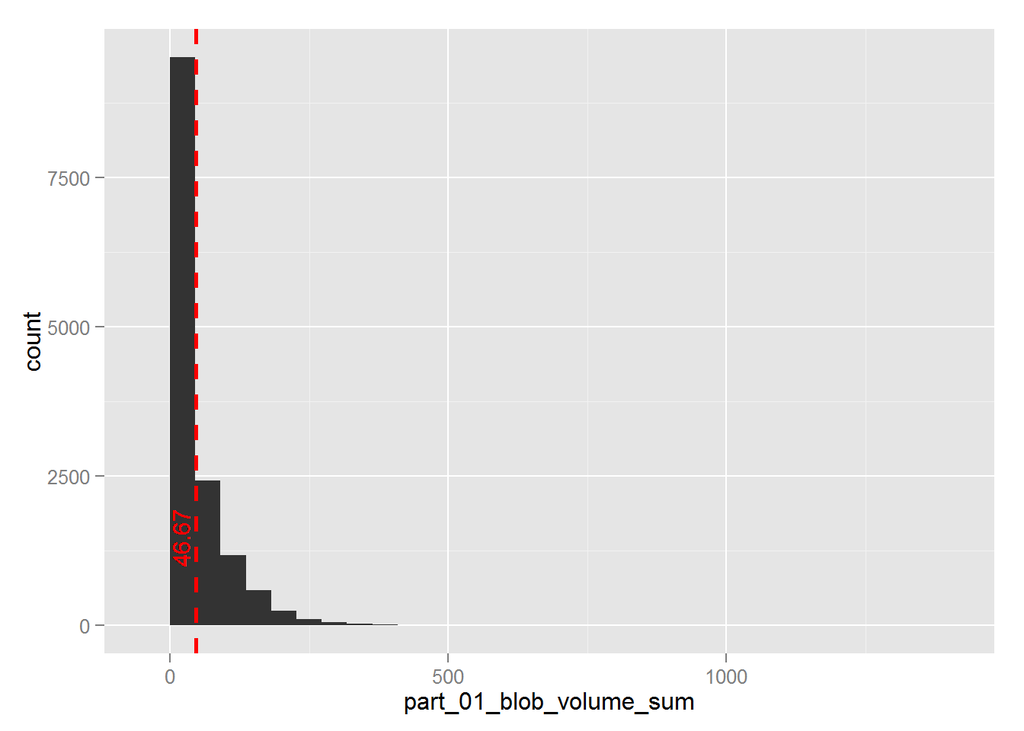

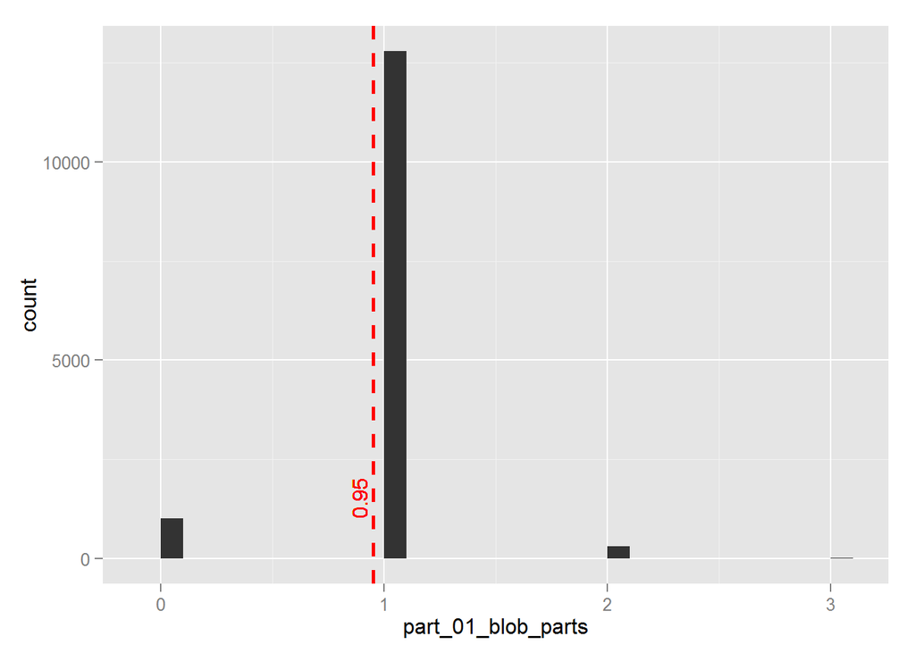

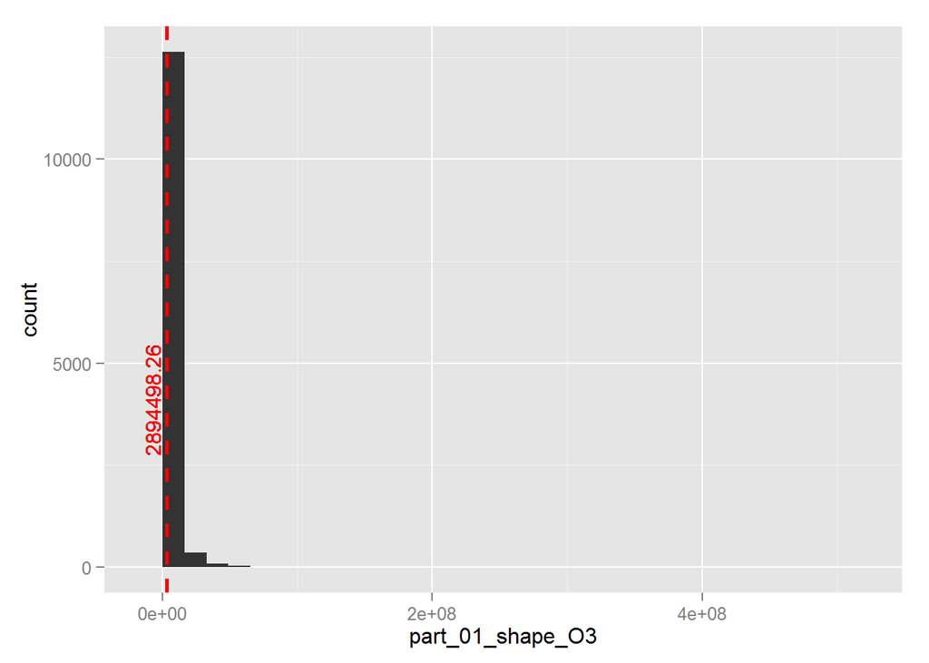

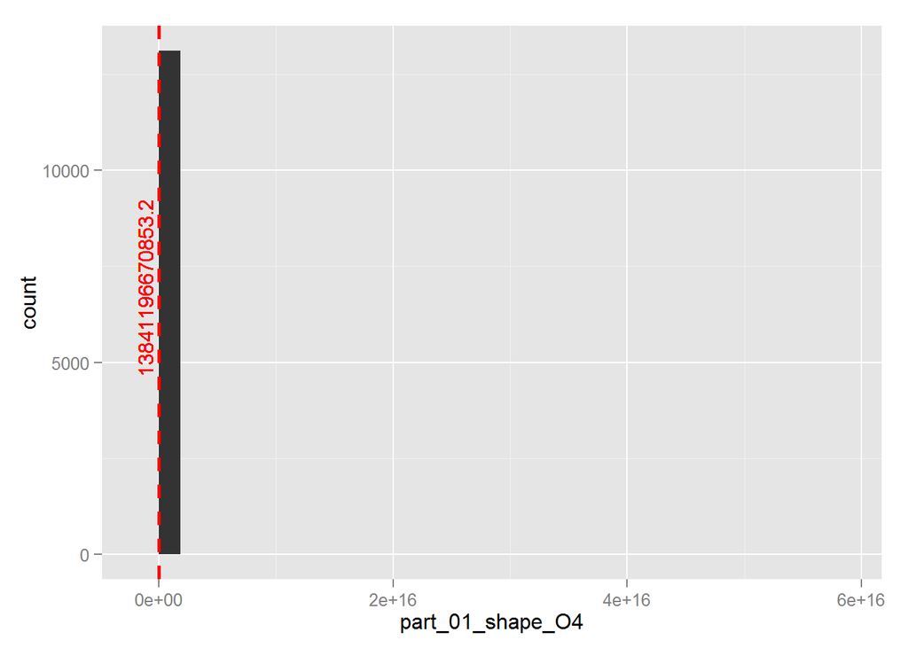

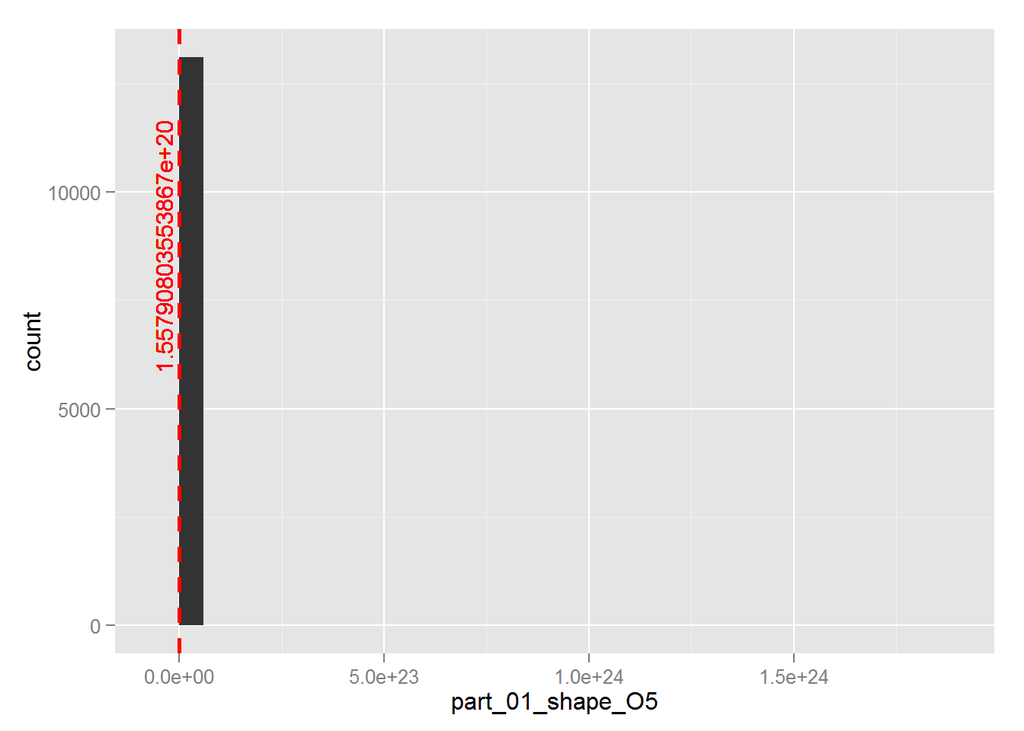

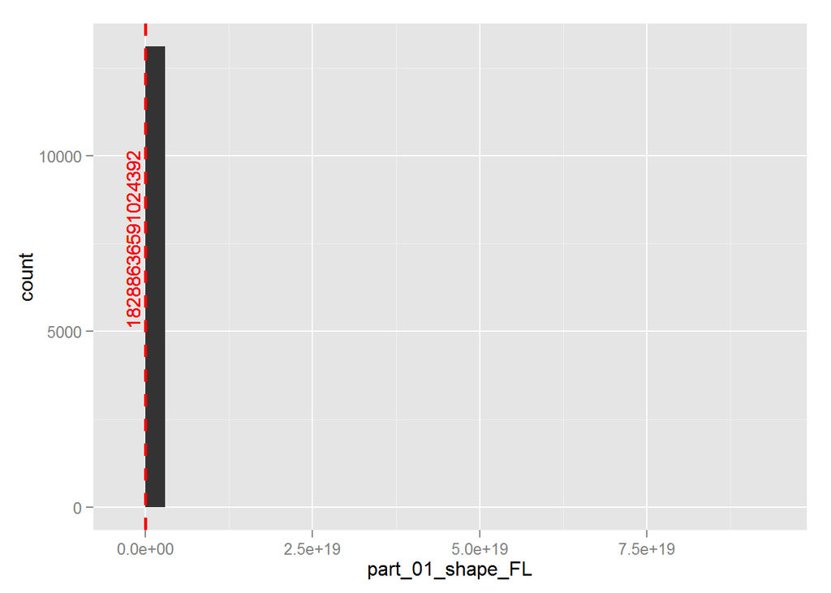

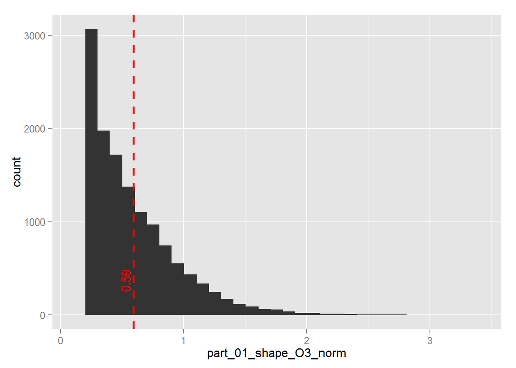

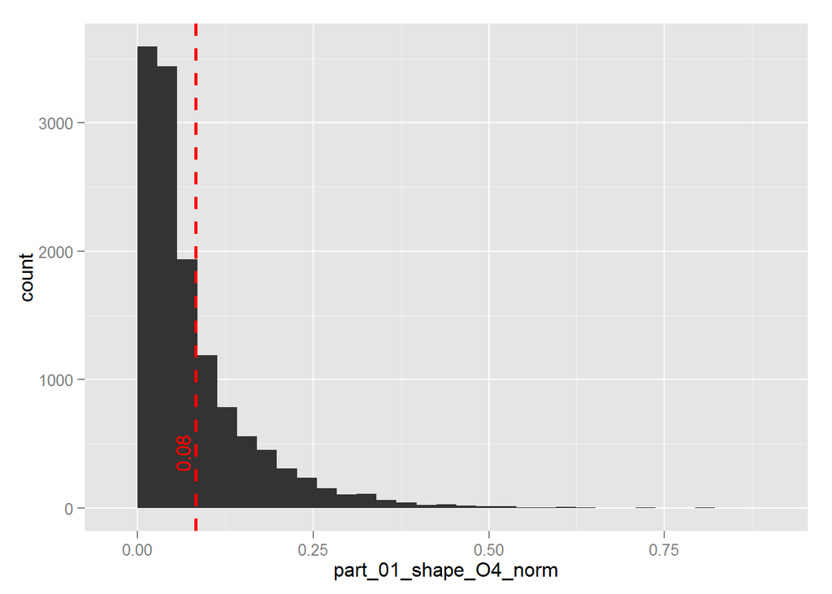

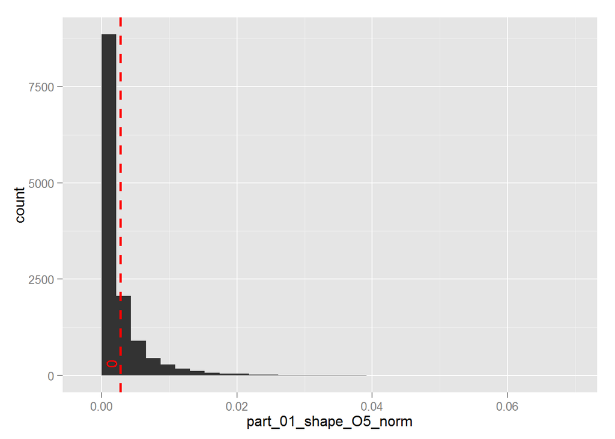

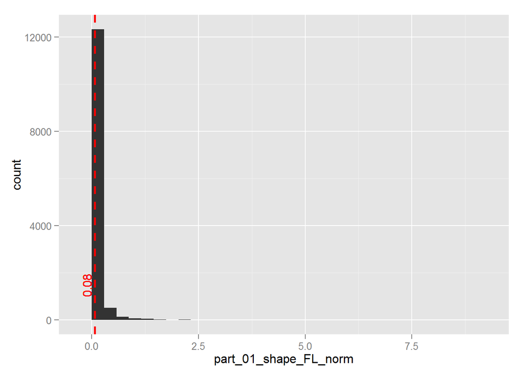

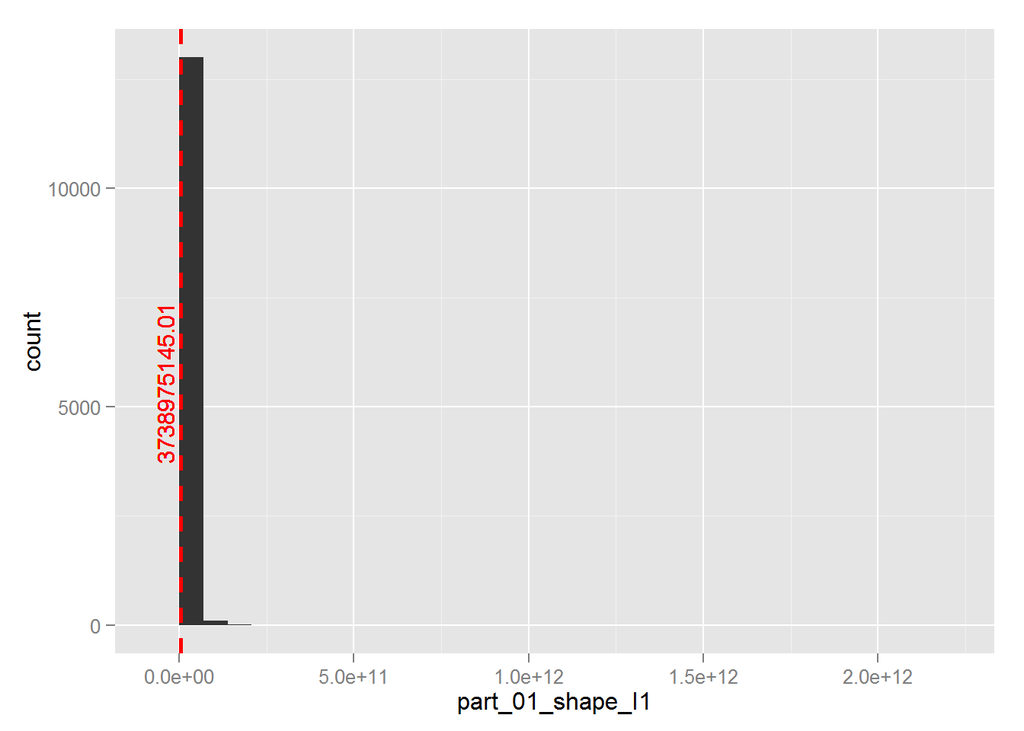

[57 more figures not shown]

### Sekcja sprawdzająca czy na podstawie kolumn da się przewidzieć liczbę atomów i elektronów

|  | r^2 | RMSE |
| --- | --- | --- |
| local_res_atom_non_h_electron_sum | 0.9999984 | 0.1769110 |
| local_res_atom_non_h_count | 0.9999997 | 0.0119695 |

|  | r^2 | RMSE |
| --- | --- | --- |
| dict_atom_non_h_electron_sum | 0.992948 | 10.16359 |
| local_res_atom_non_h_electron_occupancy_sum | 0.985355 | 14.64681 |
| local_res_atom_non_h_count | 0.960946 | 23.91803 |
| dict_atom_non_h_count | 0.952881 | 26.27205 |
| local_res_atom_non_h_occupancy_sum | 0.949419 | 27.22010 |
| local_res_atom_count | 0.948789 | 27.38892 |
| local_res_atom_C_count | 0.765464 | 58.61377 |
| dict_atom_C_count | 0.753682 | 60.06799 |
| local_res_atom_N_count | 0.729755 | 62.91787 |
| dict_atom_N_count | 0.729384 | 62.96110 |
| local_res_atom_O_count | 0.629738 | 73.64616 |
| dict_atom_O_count | 0.622211 | 74.39096 |

|  | r^2 | RMSE |
| --- | --- | --- |
| dict_atom_non_h_count | 0.992445 | 1.596211 |
| local_res_atom_non_h_occupancy_sum | 0.990560 | 1.784307 |
| local_res_atom_count | 0.987746 | 2.032889 |
| local_res_atom_non_h_electron_sum | 0.960946 | 3.629158 |
| dict_atom_non_h_electron_sum | 0.955287 | 3.883229 |
| local_res_atom_non_h_electron_occupancy_sum | 0.954757 | 3.906174 |
| local_res_atom_C_count | 0.860879 | 6.849702 |
| dict_atom_C_count | 0.847467 | 7.172294 |
| local_res_atom_N_count | 0.751109 | 9.161796 |
| dict_atom_N_count | 0.750391 | 9.175003 |
| local_res_atom_O_count | 0.608303 | 11.493456 |
| dict_atom_O_count | 0.602708 | 11.575256 |

### Klasyfikator

```
##
## Call:
## summary.resamples(object = resamps)
##
## Models: RF, KNN, LB
## Number of resamples: 4
##
## Accuracy
##       Min. 1st Qu. Median   Mean 3rd Qu.   Max. NA's
## RF  0.9631  0.9645 0.9658 0.9656  0.9669 0.9675    0
## KNN 0.1315  0.1332 0.1340 0.1359  0.1367 0.1442    0
## LB  0.9705  0.9723 0.9746 0.9748  0.9771 0.9797    0
##
## Kappa
##        Min. 1st Qu.  Median    Mean 3rd Qu.    Max. NA's
## RF  0.96070 0.96210 0.96350 0.96320 0.96470 0.96530    0
## KNN 0.02878 0.02893 0.03007 0.03218 0.03332 0.03978    0
## LB  0.96810 0.97010 0.97260 0.97280 0.97530 0.97810    0
```

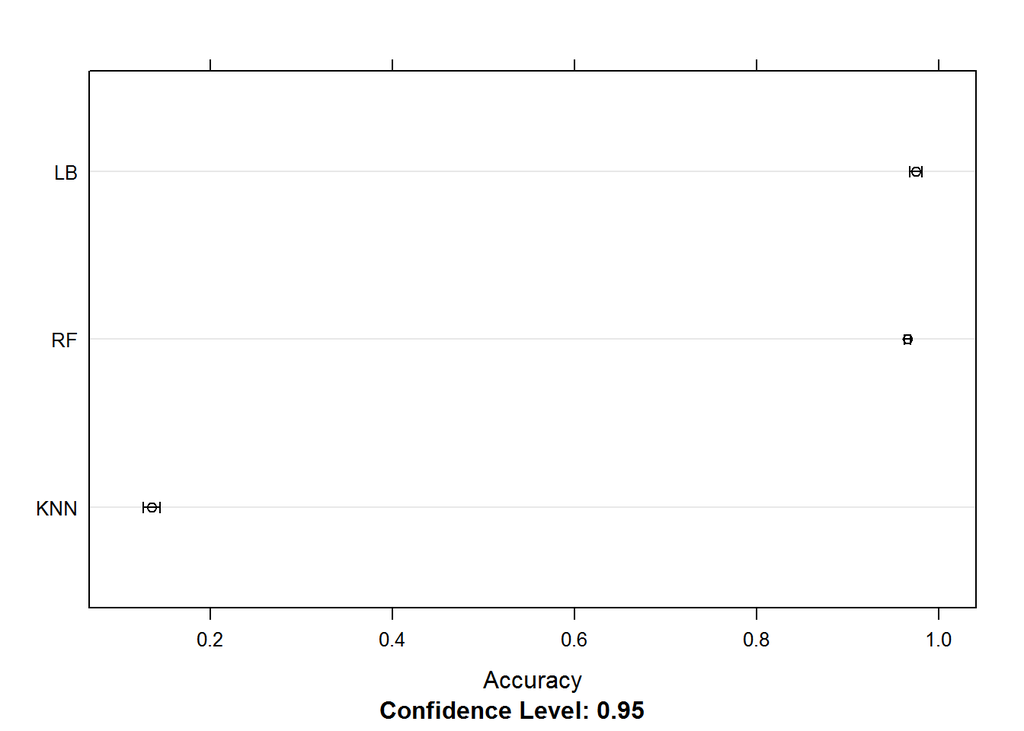

|  | ACT | ADP | ATP | BME | CA | CD | CIT | CL | CO | CU | EDO | EPE | FAD | FE | FE2 | FMN | GDP | GOL | HEM | K | MAN | MES | MG | MN | MPD | NAD | NAG | NAP | NDP | … |
| --- | --- | --- | --- | --- | --- | --- | --- | --- | --- | --- | --- | --- | --- | --- | --- | --- | --- | --- | --- | --- | --- | --- | --- | --- | --- | --- | --- | --- | --- | --- |
| ACT | 1 | 0 | 0 | 0 | 0 | 0 | 0 | 0 | 0 | 0 | 1 | 0 | 0 | 0 | 0 | 0 | 0 | 0 | 0 | 0 | 0 | 0 | 0 | 0 | 0 | 0 | 0 | 0 | 0 | … |
| ADP | 0 | 40 | 0 | 0 | 0 | 0 | 0 | 0 | 0 | 0 | 0 | 0 | 0 | 0 | 0 | 0 | 0 | 0 | 0 | 0 | 0 | 0 | 0 | 0 | 0 | 0 | 0 | 0 | 0 | … |
| ATP | 0 | 0 | 31 | 0 | 0 | 0 | 0 | 0 | 0 | 0 | 0 | 0 | 0 | 0 | 0 | 0 | 0 | 0 | 0 | 0 | 0 | 0 | 0 | 0 | 0 | 0 | 0 | 0 | 0 | … |
| BME | 0 | 0 | 0 | 20 | 0 | 0 | 0 | 0 | 0 | 0 | 0 | 0 | 0 | 0 | 0 | 0 | 0 | 0 | 0 | 0 | 0 | 0 | 0 | 0 | 0 | 0 | 0 | 0 | 0 | … |
| CA | 0 | 0 | 0 | 0 | 195 | 0 | 0 | 0 | 0 | 0 | 0 | 0 | 0 | 0 | 0 | 0 | 0 | 0 | 0 | 0 | 0 | 0 | 0 | 0 | 0 | 0 | 0 | 0 | 0 | … |
| CD | 0 | 0 | 0 | 0 | 0 | 7 | 0 | 0 | 0 | 0 | 0 | 0 | 0 | 0 | 0 | 0 | 0 | 0 | 0 | 0 | 0 | 0 | 0 | 0 | 0 | 0 | 0 | 0 | 0 | … |
| CIT | 0 | 0 | 0 | 0 | 0 | 0 | 16 | 0 | 0 | 0 | 0 | 0 | 0 | 0 | 0 | 0 | 0 | 0 | 0 | 0 | 0 | 0 | 0 | 0 | 0 | 0 | 0 | 0 | 0 | … |
| CL | 0 | 0 | 0 | 0 | 0 | 0 | 0 | 118 | 0 | 0 | 0 | 0 | 0 | 0 | 0 | 0 | 0 | 0 | 0 | 0 | 0 | 0 | 0 | 0 | 0 | 0 | 0 | 0 | 0 | … |
| CO | 0 | 0 | 0 | 0 | 0 | 0 | 0 | 0 | 12 | 0 | 0 | 0 | 0 | 0 | 0 | 0 | 0 | 0 | 0 | 0 | 0 | 0 | 0 | 0 | 0 | 0 | 0 | 0 | 0 | … |
| CU | 0 | 0 | 0 | 0 | 0 | 0 | 0 | 0 | 0 | 20 | 0 | 0 | 0 | 0 | 0 | 0 | 0 | 0 | 0 | 0 | 0 | 0 | 0 | 0 | 0 | 0 | 0 | 0 | 0 | … |
| EDO | 22 | 0 | 0 | 0 | 0 | 0 | 0 | 0 | 0 | 0 | 52 | 0 | 0 | 0 | 0 | 0 | 0 | 0 | 0 | 0 | 0 | 0 | 0 | 0 | 0 | 0 | 0 | 0 | 0 | … |
| EPE | 0 | 0 | 0 | 0 | 0 | 0 | 0 | 0 | 0 | 0 | 0 | 20 | 0 | 0 | 0 | 0 | 0 | 0 | 0 | 0 | 0 | 0 | 0 | 0 | 0 | 0 | 0 | 0 | 0 | … |
| FAD | 0 | 0 | 0 | 0 | 0 | 0 | 0 | 0 | 0 | 0 | 0 | 0 | 47 | 0 | 0 | 0 | 0 | 0 | 0 | 0 | 0 | 0 | 0 | 0 | 0 | 0 | 0 | 0 | 0 | … |
| FE | 0 | 0 | 0 | 0 | 0 | 0 | 0 | 0 | 0 | 0 | 0 | 0 | 0 | 14 | 5 | 0 | 0 | 0 | 0 | 0 | 0 | 0 | 0 | 0 | 0 | 0 | 0 | 0 | 0 | … |
| FE2 | 0 | 0 | 0 | 0 | 0 | 0 | 0 | 0 | 0 | 0 | 0 | 0 | 0 | 0 | 0 | 0 | 0 | 0 | 0 | 0 | 0 | 0 | 0 | 0 | 0 | 0 | 0 | 0 | 0 | … |
| FMN | 0 | 0 | 0 | 0 | 0 | 0 | 0 | 0 | 0 | 0 | 0 | 0 | 0 | 0 | 0 | 21 | 0 | 0 | 0 | 0 | 0 | 0 | 0 | 0 | 0 | 0 | 0 | 0 | 0 | … |
| GDP | 0 | 0 | 0 | 0 | 0 | 0 | 0 | 0 | 0 | 0 | 0 | 0 | 0 | 0 | 0 | 0 | 15 | 0 | 0 | 0 | 0 | 0 | 0 | 0 | 0 | 0 | 0 | 0 | 0 | … |
| GOL | 0 | 0 | 0 | 0 | 0 | 0 | 0 | 0 | 0 | 0 | 0 | 0 | 0 | 0 | 0 | 0 | 0 | 230 | 0 | 0 | 0 | 0 | 0 | 0 | 0 | 0 | 0 | 0 | 0 | … |
| HEM | 0 | 0 | 0 | 0 | 0 | 0 | 0 | 0 | 0 | 0 | 0 | 0 | 0 | 0 | 0 | 0 | 0 | 0 | 86 | 0 | 0 | 0 | 0 | 0 | 0 | 0 | 0 | 0 | 0 | … |
| K | 0 | 0 | 0 | 0 | 0 | 0 | 0 | 0 | 0 | 0 | 0 | 0 | 0 | 0 | 0 | 0 | 0 | 0 | 0 | 34 | 0 | 0 | 0 | 0 | 0 | 0 | 0 | 0 | 0 | … |
| MAN | 0 | 0 | 0 | 0 | 0 | 0 | 0 | 0 | 0 | 0 | 0 | 0 | 0 | 0 | 0 | 0 | 0 | 0 | 0 | 0 | 9 | 0 | 0 | 0 | 0 | 0 | 0 | 0 | 0 | … |
| MES | 0 | 0 | 0 | 0 | 0 | 0 | 0 | 0 | 0 | 0 | 0 | 0 | 0 | 0 | 0 | 0 | 0 | 0 | 0 | 0 | 0 | 23 | 0 | 0 | 0 | 0 | 0 | 0 | 0 | … |
| MG | 0 | 0 | 0 | 0 | 0 | 0 | 0 | 0 | 0 | 0 | 0 | 0 | 0 | 0 | 0 | 0 | 0 | 0 | 0 | 0 | 0 | 0 | 116 | 0 | 0 | 0 | 0 | 0 | 0 | … |
| MN | 0 | 0 | 0 | 0 | 0 | 0 | 0 | 0 | 0 | 0 | 0 | 0 | 0 | 0 | 0 | 0 | 0 | 0 | 0 | 0 | 0 | 0 | 0 | 53 | 0 | 0 | 0 | 0 | 0 | … |
| MPD | 0 | 0 | 0 | 0 | 0 | 0 | 0 | 0 | 0 | 0 | 0 | 0 | 0 | 0 | 0 | 0 | 0 | 0 | 0 | 0 | 0 | 0 | 0 | 0 | 15 | 0 | 0 | 0 | 0 | … |
| NAD | 0 | 0 | 0 | 0 | 0 | 0 | 0 | 0 | 0 | 0 | 0 | 0 | 0 | 0 | 0 | 0 | 0 | 0 | 0 | 0 | 0 | 0 | 0 | 0 | 0 | 24 | 0 | 0 | 0 | … |
| NAG | 0 | 0 | 0 | 0 | 0 | 0 | 0 | 0 | 0 | 0 | 0 | 0 | 0 | 0 | 0 | 0 | 0 | 0 | 0 | 0 | 0 | 0 | 0 | 0 | 0 | 0 | 115 | 0 | 0 | … |
| NAP | 0 | 0 | 0 | 0 | 0 | 0 | 0 | 0 | 0 | 0 | 0 | 0 | 0 | 0 | 0 | 0 | 0 | 0 | 0 | 0 | 0 | 0 | 0 | 0 | 0 | 0 | 0 | 11 | 7 | … |
| NDP | 0 | 0 | 0 | 0 | 0 | 0 | 0 | 0 | 0 | 0 | 0 | 0 | 0 | 0 | 0 | 0 | 0 | 0 | 0 | 0 | 0 | 0 | 0 | 0 | 0 | 0 | 0 | 3 | 3 | … |
| NI | 0 | 0 | 0 | 0 | 0 | 0 | 0 | 0 | 0 | 0 | 0 | 0 | 0 | 0 | 0 | 0 | 0 | 0 | 0 | 0 | 0 | 0 | 0 | 0 | 0 | 0 | 0 | 0 | 0 | … |
| PEG | 0 | 0 | 0 | 0 | 0 | 0 | 0 | 0 | 0 | 0 | 0 | 0 | 0 | 0 | 0 | 0 | 0 | 0 | 0 | 0 | 0 | 0 | 0 | 0 | 0 | 0 | 0 | 0 | 0 | … |
| PG4 | 0 | 0 | 0 | 0 | 0 | 0 | 0 | 0 | 0 | 0 | 0 | 0 | 0 | 0 | 0 | 0 | 0 | 0 | 0 | 0 | 0 | 0 | 0 | 0 | 0 | 0 | 0 | 0 | 0 | … |
| PLP | 0 | 0 | 0 | 0 | 0 | 0 | 0 | 0 | 0 | 0 | 0 | 0 | 0 | 0 | 0 | 0 | 0 | 0 | 0 | 0 | 0 | 0 | 0 | 0 | 0 | 0 | 0 | 0 | 0 | … |
| PO4 | 0 | 0 | 0 | 0 | 0 | 0 | 0 | 0 | 0 | 0 | 0 | 0 | 0 | 0 | 0 | 0 | 0 | 0 | 0 | 0 | 0 | 0 | 0 | 0 | 0 | 0 | 0 | 0 | 0 | … |
| SAH | 0 | 0 | 0 | 0 | 0 | 0 | 0 | 0 | 0 | 0 | 0 | 0 | 0 | 0 | 0 | 0 | 0 | 0 | 0 | 0 | 0 | 0 | 0 | 0 | 0 | 0 | 0 | 0 | 0 | … |
| SEP | 0 | 0 | 0 | 0 | 0 | 0 | 0 | 0 | 0 | 0 | 0 | 0 | 0 | 0 | 0 | 0 | 0 | 0 | 0 | 0 | 0 | 0 | 0 | 0 | 0 | 0 | 0 | 0 | 0 | … |
| SO4 | 0 | 0 | 0 | 0 | 0 | 0 | 0 | 0 | 0 | 0 | 0 | 0 | 0 | 0 | 0 | 0 | 0 | 0 | 0 | 0 | 0 | 0 | 0 | 0 | 0 | 0 | 0 | 0 | 0 | … |
| TPO | 0 | 0 | 0 | 0 | 0 | 0 | 0 | 0 | 0 | 0 | 0 | 0 | 0 | 0 | 0 | 0 | 0 | 0 | 0 | 0 | 0 | 0 | 0 | 0 | 0 | 0 | 0 | 0 | 0 | … |
| TRS | 0 | 0 | 0 | 0 | 0 | 0 | 0 | 0 | 0 | 0 | 0 | 0 | 0 | 0 | 0 | 0 | 0 | 0 | 0 | 0 | 0 | 0 | 0 | 0 | 0 | 0 | 0 | 0 | 0 | … |
| ZN | 0 | 0 | 0 | 0 | 0 | 1 | 0 | 0 | 1 | 0 | 0 | 0 | 0 | 1 | 1 | 0 | 0 | 0 | 0 | 0 | 0 | 0 | 0 | 0 | 0 | 0 | 0 | 0 | 0 | … |

| Accuracy | 0.9782904 |
| --- | --- |
| Kappa | 0.9766051 |
| AccuracyLower | 0.9713183 |
| AccuracyUpper | 0.9839507 |
| AccuracyNull | 0.1573948 |
| AccuracyPValue | 0.0000000 |
| McnemarPValue | NaN |

|  | Sensitivity | Specificity | Pos Pred Value | Neg Pred Value | Prevalence | Detection Rate | Detection Prevalence | Balanced Accuracy |
| --- | --- | --- | --- | --- | --- | --- | --- | --- |
| Class: ACT | 0.0434783 | 0.9995430 | 0.5000000 | 0.9900407 | 0.0104025 | 0.0004523 | 0.0009046 | 0.5215106 |
| Class: ADP | 1.0000000 | 1.0000000 | 1.0000000 | 1.0000000 | 0.0180914 | 0.0180914 | 0.0180914 | 1.0000000 |
| Class: ATP | 1.0000000 | 1.0000000 | 1.0000000 | 1.0000000 | 0.0140208 | 0.0140208 | 0.0140208 | 1.0000000 |
| Class: BME | 1.0000000 | 1.0000000 | 1.0000000 | 1.0000000 | 0.0090457 | 0.0090457 | 0.0090457 | 1.0000000 |
| Class: CA | 1.0000000 | 1.0000000 | 1.0000000 | 1.0000000 | 0.0881954 | 0.0881954 | 0.0881954 | 1.0000000 |
| Class: CD | 0.8750000 | 1.0000000 | 1.0000000 | 0.9995463 | 0.0036183 | 0.0031660 | 0.0031660 | 0.9375000 |
| Class: CIT | 1.0000000 | 1.0000000 | 1.0000000 | 1.0000000 | 0.0072365 | 0.0072365 | 0.0072365 | 1.0000000 |
| Class: CL | 1.0000000 | 1.0000000 | 1.0000000 | 1.0000000 | 0.0533695 | 0.0533695 | 0.0533695 | 1.0000000 |
| Class: CO | 0.9230769 | 1.0000000 | 1.0000000 | 0.9995452 | 0.0058797 | 0.0054274 | 0.0054274 | 0.9615385 |
| Class: CU | 1.0000000 | 1.0000000 | 1.0000000 | 1.0000000 | 0.0090457 | 0.0090457 | 0.0090457 | 1.0000000 |
| Class: EDO | 0.9811321 | 0.9898054 | 0.7027027 | 0.9995321 | 0.0239711 | 0.0235188 | 0.0334690 | 0.9854687 |
| Class: EPE | 1.0000000 | 1.0000000 | 1.0000000 | 1.0000000 | 0.0090457 | 0.0090457 | 0.0090457 | 1.0000000 |
| Class: FAD | 1.0000000 | 1.0000000 | 1.0000000 | 1.0000000 | 0.0212573 | 0.0212573 | 0.0212573 | 1.0000000 |
| Class: FE | 0.9333333 | 0.9977231 | 0.7368421 | 0.9995438 | 0.0067843 | 0.0063320 | 0.0085934 | 0.9655282 |
| Class: FE2 | 0.0000000 | 1.0000000 | NaN | 0.9972863 | 0.0027137 | 0.0000000 | 0.0000000 | 0.5000000 |
| Class: FMN | 1.0000000 | 1.0000000 | 1.0000000 | 1.0000000 | 0.0094980 | 0.0094980 | 0.0094980 | 1.0000000 |
| Class: GDP | 1.0000000 | 1.0000000 | 1.0000000 | 1.0000000 | 0.0067843 | 0.0067843 | 0.0067843 | 1.0000000 |
| Class: GOL | 1.0000000 | 1.0000000 | 1.0000000 | 1.0000000 | 0.1040253 | 0.1040253 | 0.1040253 | 1.0000000 |
| Class: HEM | 1.0000000 | 1.0000000 | 1.0000000 | 1.0000000 | 0.0388964 | 0.0388964 | 0.0388964 | 1.0000000 |
| Class: K | 1.0000000 | 1.0000000 | 1.0000000 | 1.0000000 | 0.0153777 | 0.0153777 | 0.0153777 | 1.0000000 |
| Class: MAN | 1.0000000 | 1.0000000 | 1.0000000 | 1.0000000 | 0.0040706 | 0.0040706 | 0.0040706 | 1.0000000 |
| Class: MES | 1.0000000 | 1.0000000 | 1.0000000 | 1.0000000 | 0.0104025 | 0.0104025 | 0.0104025 | 1.0000000 |
| Class: MG | 1.0000000 | 1.0000000 | 1.0000000 | 1.0000000 | 0.0524649 | 0.0524649 | 0.0524649 | 1.0000000 |
| Class: MN | 1.0000000 | 1.0000000 | 1.0000000 | 1.0000000 | 0.0239711 | 0.0239711 | 0.0239711 | 1.0000000 |
| Class: MPD | 1.0000000 | 1.0000000 | 1.0000000 | 1.0000000 | 0.0067843 | 0.0067843 | 0.0067843 | 1.0000000 |
| Class: NAD | 1.0000000 | 1.0000000 | 1.0000000 | 1.0000000 | 0.0108548 | 0.0108548 | 0.0108548 | 1.0000000 |
| Class: NAG | 1.0000000 | 1.0000000 | 1.0000000 | 1.0000000 | 0.0520127 | 0.0520127 | 0.0520127 | 1.0000000 |
| Class: NAP | 0.7857143 | 0.9968138 | 0.6111111 | 0.9986320 | 0.0063320 | 0.0049751 | 0.0081411 | 0.8912641 |
| Class: NDP | 0.3000000 | 0.9986370 | 0.5000000 | 0.9968254 | 0.0045228 | 0.0013569 | 0.0027137 | 0.6493185 |
| Class: NI | 0.6875000 | 1.0000000 | 1.0000000 | 0.9977273 | 0.0072365 | 0.0049751 | 0.0049751 | 0.8437500 |
| Class: PEG | 1.0000000 | 1.0000000 | 1.0000000 | 1.0000000 | 0.0122117 | 0.0122117 | 0.0122117 | 1.0000000 |
| Class: PG4 | 0.9411765 | 1.0000000 | 1.0000000 | 0.9995444 | 0.0076888 | 0.0072365 | 0.0072365 | 0.9705882 |
| Class: PLP | 1.0000000 | 1.0000000 | 1.0000000 | 1.0000000 | 0.0076888 | 0.0076888 | 0.0076888 | 1.0000000 |
| Class: PO4 | 1.0000000 | 0.9995287 | 0.9888889 | 1.0000000 | 0.0402533 | 0.0402533 | 0.0407056 | 0.9997644 |
| Class: SAH | 1.0000000 | 1.0000000 | 1.0000000 | 1.0000000 | 0.0072365 | 0.0072365 | 0.0072365 | 1.0000000 |
| Class: SEP | 1.0000000 | 1.0000000 | 1.0000000 | 1.0000000 | 0.0076888 | 0.0076888 | 0.0076888 | 1.0000000 |
| Class: SO4 | 1.0000000 | 1.0000000 | 1.0000000 | 1.0000000 | 0.1573948 | 0.1573948 | 0.1573948 | 1.0000000 |
| Class: TPO | 1.0000000 | 1.0000000 | 1.0000000 | 1.0000000 | 0.0040706 | 0.0040706 | 0.0040706 | 1.0000000 |
| Class: TRS | 1.0000000 | 1.0000000 | 1.0000000 | 1.0000000 | 0.0067843 | 0.0067843 | 0.0067843 | 1.0000000 |
| Class: ZN | 1.0000000 | 0.9954105 | 0.9652510 | 1.0000000 | 0.1130710 | 0.1130710 | 0.1171416 | 0.9977053 |